# Trabajo de Inferencia Causal: Datos de cartera de seguros

Ciencia de Datos en Negocio, Máster en Ciencia de Datos, UV.

Maria Gómez Mahiques

Jorge Huerta Muñoz

Cayetano Romero Monteagudo

Cristina Vicedo Revert

04-06-2023

El objetivo de este trabajo es abordar un problema de inferencia causal en un contexto socio-económico, en este caso haciendo uso de una serie de datos procedentes a una cartera de seguros. Se analizará la influencia del tipo de coche asegurado sobre la siniestralidad.

El dataset cuenta con una gran cantidad de variables : edad del cliente, fecha de inicio y vencimiento de la póliza, marca y cilindrada del vehículo, número de siniestros y el coste asociado, entre otras.

# 1 Descripción del problema

## 1.1 Análisis exploratorio

En primer lugar se realiza un análisis exploratorio de los datos con el objetivo de analizar qué variables son de interés para el estudio y cuáles se pueden descartar, así como para ver posibles correlaciones o relaciones relevantes que se puedan dar entre las variables presentes.

```r
seguros <- read_excel("seguro_automovil_causal.xlsx")

str(seguros)
```

```
tibble [25,000 × 30] (S3: tbl_df/tbl/data.frame)
 $ poliza          : num [1:25000] 332793 332824 332905 372944 382210 ...
 $ Edad            : num [1:25000] 67 48 58 56 68 70 55 42 51 55 ...
 $ Carne           : num [1:25000] 47 30 38 38 48 50 37 24 33 36 ...
 $ Expo            : num [1:25000] 6 19 365 32 365 16 178 180 110 180 ...
 $ fini            : POSIXct[1:25000], format: "2018-01-01" "2018-01-01" ...
 $ fvto            : POSIXct[1:25000], format: "2018-01-06" "2018-01-19" ...
 $ fpag            : num [1:25000] 1 5 5 1 1 1 1 99 5 1 ...
 $ C_postal        : chr [1:25000] "03820" "03802" "03820" "03830" ...
 $ Veh_marca       : chr [1:25000] "MERCEDES" "SKODA" "TOYOTA" "VOLKSWAGEN" ...
 $ Veh_cdin        : num [1:25000] 650 193 170 450 650 265 110 265 125 115 ...
 $ Veh_val         : num [1:25000] 571266 29048 48557 148366 571331 ...
 $ Veh_cuso        : num [1:25000] 3 3 3 3 3 3 3 3 3 3 ...
 $ Veh_peso        : num [1:25000] 1707 1453 2394 2338 1712 ...
 $ Veh_comb        : chr [1:25000] "G" "G" "D" "G" ...
```

[output cut: 16 more lines]

```r
summary(seguros)
```

```
     poliza            Edad             Carne           Expo
 Min.   :332793   Min.   :  15.00   Min.   : 0.0   Min.   :  0.0
 1st Qu.:743912   1st Qu.:  38.00   1st Qu.:17.0   1st Qu.:116.0
 Median :777231   Median :  49.00   Median :28.0   Median :193.0
 Mean   :772136   Mean   :  49.49   Mean   :26.9   Mean   :216.4
 3rd Qu.:803026   3rd Qu.:  58.00   3rd Qu.:36.0   3rd Qu.:365.0
 Max.   :834080   Max.   :9999.00   Max.   :70.0   Max.   :730.0
      fini                             fvto
 Min.   :2018-01-01 00:00:00.00   Min.   :2017-12-31 00:00:00.00
 1st Qu.:2018-01-01 00:00:00.00   1st Qu.:2018-07-27 00:00:00.00
 Median :2018-03-02 00:00:00.00   Median :2018-12-31 00:00:00.00
 Mean   :2018-04-25 03:00:20.74   Mean   :2018-11-26 12:25:31.00
 3rd Qu.:2018-08-01 00:00:00.00   3rd Qu.:2019-02-01 00:00:00.00
 Max.   :2019-01-01 00:00:00.00   Max.   :2019-12-31 00:00:00.00
      fpag         C_postal          Veh_marca            Veh_cdin
 Min.   : 1.00   Length:25000       Length:25000       Min.   :  5.0
 1st Qu.: 1.00   Class :character   Class :character   1st Qu.: 90.0
 Median : 5.00   Mode  :character   Mode  :character   Median :109.0
 Mean   :32.61                                         Mean   :111.9
 3rd Qu.:99.00                                         3rd Qu.:125.0
 Max.   :99.00                                         Max.   :776.0
    Veh_val           Veh_cuso        Veh_peso      Veh_comb
 Min.   :   -990   Min.   :3.000   Min.   : 300   Length:25000
 1st Qu.:  16492   1st Qu.:3.000   1st Qu.:1108   Class :character
 Median :  21306   Median :3.000   Median :1241   Mode  :character
 Mean   :  24255   Mean   :3.087   Mean   :1257
 3rd Qu.:  26472   3rd Qu.:3.000   3rd Qu.:1384
 Max.   :5849175   Max.   :4.000   Max.   :2556
   Cus_des             N_rcmat          N_rccorp         N_culpa
 Length:25000       Min.   :0.0000   Min.   :0.0000   Min.   :0.00000
 Class :character   1st Qu.:0.0000   1st Qu.:0.0000   1st Qu.:0.00000
 Mode  :character   Median :0.0000   Median :0.0000   Median :0.00000
                    Mean   :0.1002   Mean   :0.0112   Mean   :0.03996
                    3rd Qu.:0.0000   3rd Qu.:0.0000   3rd Qu.:0.00000
                    Max.   :4.0000   Max.   :2.0000   Max.   :3.00000
     N_inoc       C_rcmat_culpa      C_rcmat_inoc       C_rcmat_agregado
 Min.   :0.0000   Min.   :-8877.9   Min.   :-2186.670   Min.   :-23358.20
 1st Qu.:0.0000   1st Qu.:    0.0   1st Qu.:    0.000   1st Qu.:     0.00
 Median :0.0000   Median :    0.0   Median :    0.000   Median :     0.00
 Mean   :0.0572   Mean   :   49.5   Mean   :    2.793   Mean   :    56.34
 3rd Qu.:0.0000   3rd Qu.:    0.0   3rd Qu.:    0.000   3rd Qu.:     0.00
 Max.   :4.0000   Max.   :17574.8   Max.   :18411.040   Max.   : 35109.13
    C_rccorp            veh_ant        b7_longitud     b7_puertas
 Min.   :     0.00   Min.   : 0.000   Min.   :   0   Min.   :0.000
 1st Qu.:     0.00   1st Qu.: 1.000   1st Qu.:4062   1st Qu.:5.000
 Median :     0.00   Median : 2.333   Median :4300   Median :5.000
 Mean   :    38.19   Mean   : 2.436   Mean   :4264   Mean   :4.772
 3rd Qu.:     0.00   3rd Qu.: 3.667   3rd Qu.:4426   3rd Qu.:5.000
 Max.   :182137.90   Max.   :19.000   Max.   :5522   Max.   :6.000
   Tipo_veh          clase_veh          ant_compnia         Score2
 Length:25000       Length:25000       Min.   : 0.000   Min.   : 1.000
 Class :character   Class :character   1st Qu.: 1.000   1st Qu.: 1.000
 Mode  :character   Mode  :character   Median : 1.000   Median : 2.000
                                       Mean   : 1.695   Mean   : 3.683
                                       3rd Qu.: 3.000   3rd Qu.: 6.000
                                       Max.   :19.000   Max.   :10.000
```

Para medir la siniestralidad se va a trabajar con la cantidad total de accidentes que ha tenido un vehículo,de modo que se suman los accidentes con daños materiales y con daños corporales por póliza. Esto se hace bajo la suposición de que los accidentes son únicamente de un tipo: materiales o corporales.

El tratamiento con el que se va a trabajar es si el cliente tiene un coche de coste de compra elevado. Se consdierará que el precio es alto a partir de 30.000 euros. Otro enfoque que se emplea consiste en considerar como tratamiento la experiencia o años con carnet del cliente, de modo que se introduce la variable `experiencia` de manera similar a precio, considerando como clietnes experimentados aquellos que están por encima del tercer cuantil, es decir, el 25% de clientes con más experiencia.

```r
quantile(seguros$Veh_val)
```

```
        0%        25%        50%        75%       100%
   -990.00   16491.74   21305.83   26472.49 5849175.00
```

De este modo, se eliminará la variable ‘Veh_val’ y se generará una nueva, llamada ‘precio’, de modo que se asigna un 1 a coches de más de 30.0000 euros, y un 0 al resto de vehículos.

```r
seguros$precio <- ifelse(seguros$Veh_val > 30000, 1, 0)

seguros <- seguros %>%
    mutate(coste = C_rcmat_agregado + C_rccorp)

seguros$accidente <- seguros$N_rcmat + seguros$N_rccorp

seguros$experiencia <- ifelse(seguros$Carne >= quantile(seguros$Carne, 0.75), 1,
    0)
```

```r
data <- seguros %>%
    dplyr::select(-c(C_postal, C_rcmat_culpa, C_rcmat_inoc, poliza, fini, fvto, fpag,
        Veh_marca, Veh_cuso, Veh_peso, Veh_comb, Cus_des, ant_compnia, N_rcmat, N_rccorp,
        N_culpa, N_inoc, C_rcmat_agregado, C_rccorp, b7_longitud, b7_puertas, Tipo_veh,
        clase_veh, Score2, coste))
```

```r
# table(seguros$pagar)
data
```

```
# A tibble: 25,000 × 9
    Edad Carne  Expo Veh_cdin Veh_val veh_ant precio accidente experiencia
   <dbl> <dbl> <dbl>    <dbl>   <dbl>   <dbl>  <dbl>     <dbl>       <dbl>
 1    67    47     6      650 571266       18      1         0           1
 2    48    30    19      193  29048       18      0         1           0
 3    58    38   365      170  48557.      18      1         0           1
 4    56    38    32      450 148366       17      1         0           1
 5    68    48   365      650 571331       17      1         0           1
 6    70    50    16      265  31644       16      1         0           1
 7    55    37   178      110  15901       13      0         0           1
 8    42    24   180      265  32342       13      1         0           0
 9    51    33   110      125  22540       12      0         0           0
10    55    36   180      115  22089.      11      0         0           1
# … with 24,990 more rows
```

Se calculan las correlaciones entre las variables en estudio, sin tener en cuenta el objetivo, accidente.

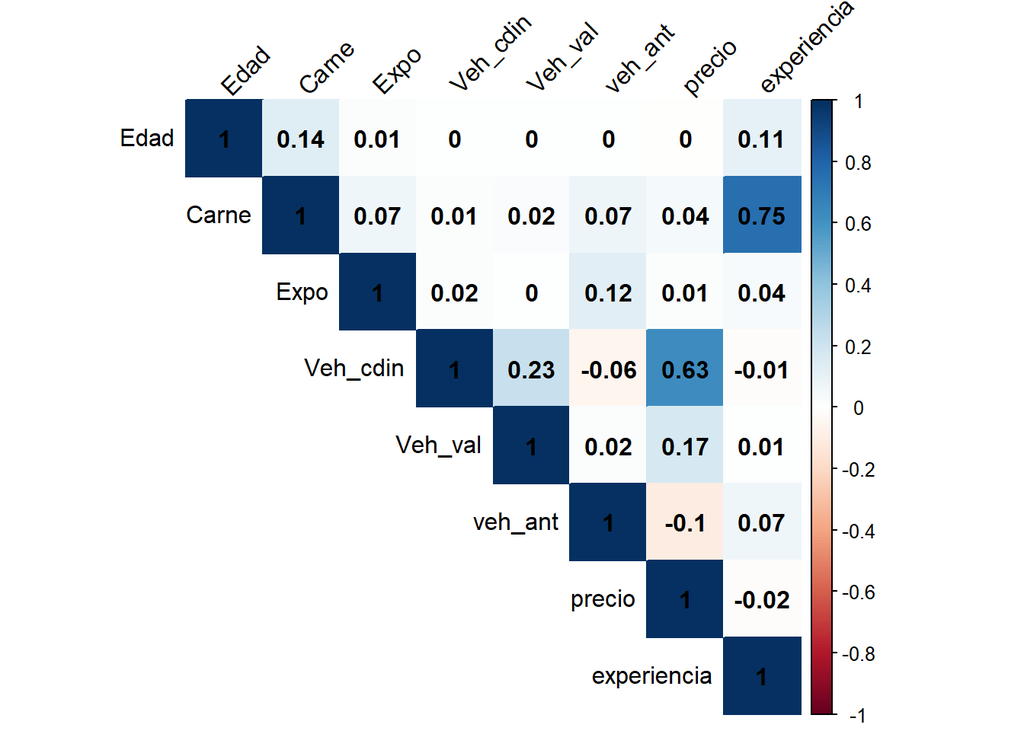

```r
# Calcular las correlaciones
data_red <- data %>%
    dplyr::select(-c(accidente))
correlation_matrix <- cor(data_red)

# Visualizar las correlaciones utilizando un mapa de calor
corrplot(correlation_matrix, method = "color", type = "upper", tl.col = "black",
    tl.srt = 45, addCoef.col = "black")
```

La variable experiencia se utilizará como tratamiento posteriormente.

Por otro lado, se realiza el test Chi-Cuadrado, que indica si hay relación entre cada una de las variables anteriores y accidente.

```r
# Crear una lista para almacenar los resultados
results <- list()

# Realizar las pruebas de chi-cuadrado
for (var in names(data_red)) {
    # Ejecutar la prueba de chi-cuadrado
    result <- chisq.test(table(data_red[[var]], data$accidente))

    # Agregar el resultado a la lista
    results[[var]] <- result
}

# Mostrar los resultados
for (var in names(results)) {
    cat("Variable:", var, "\n")
    print(results[[var]])
    cat("\n")
}
```

```
Variable: Edad

    Pearson's Chi-squared test

data:  table(data_red[[var]], data$accidente)
X-squared = 693.51, df = 405, p-value < 2.2e-16


Variable: Carne

    Pearson's Chi-squared test

data:  table(data_red[[var]], data$accidente)
X-squared = 341.75, df = 350, p-value = 0.6137


Variable: Expo

    Pearson's Chi-squared test

data:  table(data_red[[var]], data$accidente)
X-squared = 5909.7, df = 2630, p-value < 2.2e-16


Variable: Veh_cdin

    Pearson's Chi-squared test

data:  table(data_red[[var]], data$accidente)
X-squared = 541.5, df = 980, p-value = 1


Variable: Veh_val

    Pearson's Chi-squared test

data:  table(data_red[[var]], data$accidente)
X-squared = 64121, df = 67955, p-value = 1


Variable: veh_ant

    Pearson's Chi-squared test

data:  table(data_red[[var]], data$accidente)
X-squared = 7891, df = 340, p-value < 2.2e-16


Variable: precio

    Pearson's Chi-squared test

data:  table(data_red[[var]], data$accidente)
X-squared = 9.8434, df = 5, p-value = 0.0798


Variable: experiencia

    Pearson's Chi-squared test

data:  table(data_red[[var]], data$accidente)
X-squared = 16.862, df = 5, p-value = 0.00477
```

Es importante recordar que para este test se parte de la hipótesis nula de que ambas variables son independientes, así: valores altos de p-valor nos permitirán no considerar dichas variables en el estudio ya que no influirán sobre la variable a predecir. De este modo se tiene que tanto la edad como la exposición al riesgo, la antigüedad del vehículo y su precio influyen en la cantidad de accidentes si se considera un p-valor de 0.10.

Finalmente, se cuenta con las siguientes variables para realizar el estudio: Edad, Carne, veh_ant y las dos variables que se han definido expresamente para el proyecto, que son precio y accidente.

Se pasan a plantear una serie de hipótesis sobre las que trabajar, y se definen una serie de DAGs o grafos acíclicos dirigidos, que consisten en una proposición teórica de las posibles relaciones entre las variables en estudio.

## 1.2 Hipótesis

### 1.2.1 DAG complejo

El DAG siguiente es el más completo de todos, donde se contempla la posibilidad de que un gran número de variables estén relacionadas entre ellas e influyan de manera significativa sobre la siniestralidad, pero resulta muy complicado para aplicar sobre él las metodologías vistas, de modo que se optará por emplear DAGs algo más sencillos.

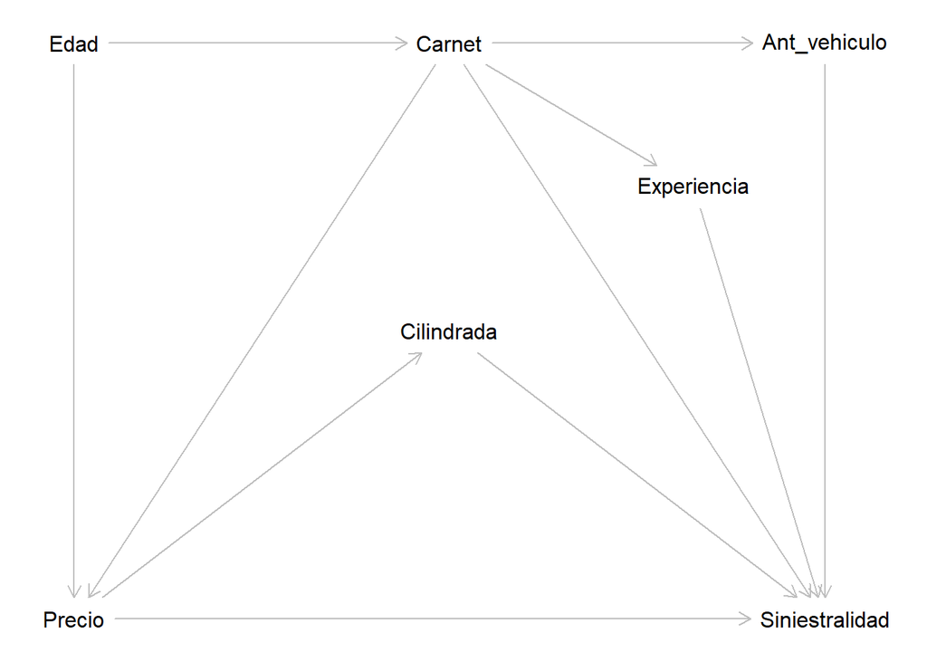

```r
dag_seguros_complejo <- dagitty("dag {
    Edad -> Carnet
    Edad -> Precio
    Precio -> Siniestralidad
    Carnet-> Siniestralidad
    Carnet-> Precio
    Precio->  Cilindrada
    Cilindrada-> Siniestralidad
    Carnet-> Ant_vehiculo
    Ant_vehiculo-> Siniestralidad
    Carnet -> Experiencia
    Experiencia -> Siniestralidad
  }")
coordinates(dag_seguros_complejo) <- list(y = c(Edad = 1, Precio = 2, Siniestralidad = 2,
    Tipo_coche = 2, Carnet = 1, Cilindrada = 1.5, Ant_vehiculo = 1, Experiencia = 1.25),
    x = c(Edad = 1, Precio = 1, Siniestralidad = 3, Tipo_coche = 2, Carnet = 2, Cilindrada = 2,
        Ant_vehiculo = 3, Experiencia = 2.65))

plot(dag_seguros_complejo)
```

### 1.2.2 DAGs más sencillo

A continuación se muestran los que serían los DAGs más sencillo, asumiendo en primer lugar que el precio del vehículo influye directamente sobre la siniestralidad, o que el factor influyente es la experiencia del conductor. En estos casos habría un efecto directo de Precio o Experiencia sobre Siniestralidad.

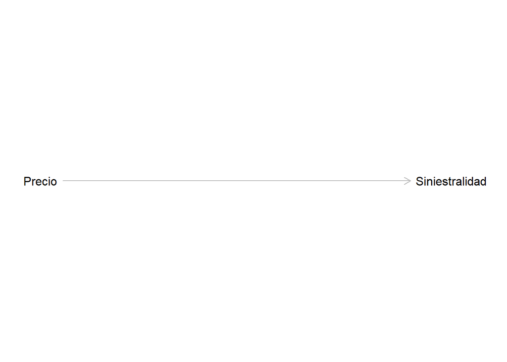

```r
dag_seguros_simple <- dagitty("dag {
    Precio -> Siniestralidad
  }")
coordinates(dag_seguros_simple) <- list(y = c(Precio = 1, Siniestralidad = 1), x = c(Precio = 1,
    Siniestralidad = 2))

plot(dag_seguros_simple)
```

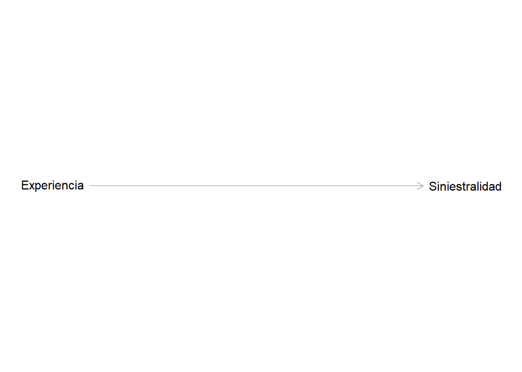

```r
dag_seguros_simple2 <- dagitty("dag {
    Experiencia -> Siniestralidad
  }")
coordinates(dag_seguros_simple2) <- list(y = c(Experiencia = 1, Siniestralidad = 1),
    x = c(Experiencia = 1, Siniestralidad = 2))

plot(dag_seguros_simple2)
```

### 1.2.3 DAG de complejidad media

En este DAG, de complejidad intermedia entre el primero y los 2 anteriores, muestra la posible influencia de la edad en las relaciones estudiadas, de modo que sería una variable de confusión. Será el caso que se estudia.

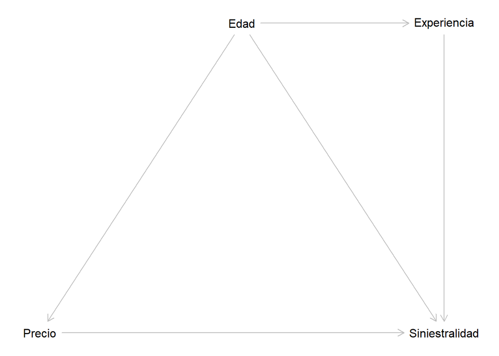

```r
dag_seguros <- dagitty("dag {
    Edad -> Siniestralidad
    Edad -> Precio
    Precio -> Siniestralidad
    Experiencia -> Siniestralidad
    Edad -> Experiencia
  }")
coordinates(dag_seguros) <- list(y = c(Precio = 0, Siniestralidad = 0, Edad = -1,
    Experiencia = -1), x = c(Precio = 0, Siniestralidad = 1, Edad = 0.5, Experiencia = 1))
exposures(dag_seguros) <- "Precio"
outcomes(dag_seguros) <- "Siniestralidad"
latents(dag_seguros) <- "Edad"

plot(dag_seguros)
```

Hay que tener en cuenta que la elaboración de la estructura y las conexiones de los grafos son una aproximación a priori y no paramétrica de la influencia de las variables entre ellas. Sirven para analizar gráficamente diferentes enfoques del problema que se quiere estudiar viendo la influencia entre variables, para una vez definido un grafo de influencias razonable, dar el paso al análisis del problema.

Para este estudio, se evaluarán los casos de PRECIO y EXPERIENCIA sobre la variable ACCIDENTE.

# 2 Selección de metodología: Caso 1, Precio.

En este caso se opta por usar métodos de matching para el ejemplo en estudio.

Se utiliza el método matching para comparar entre grupos tratados y no tratados, con el objetivo de realizar una estimación del efecto causal de la variable tratamiento. Este método sirve para equiparar las características entre individuos tratados y no tratados, para que las diferencias entre ambos conjuntos pueda atribuirse a los tratamientos, y no tanto a las diferencias entre los valores de cada una de las muestras entre ambos conjuntos.

En este caso, se parean las muestras control con los tratados. Teniendo 21098 casos de no tratados (control), se parea el número de individuos tratados con observaciones no tratadas, en total 3902 pareados, dejando sin emparejar 17196 individuos no tratados.

```r
## Matching PRECIO
m.ps.train.1 <- matchit(precio ~ Edad + Carne + veh_ant, method = "nearest", distance = "glm",
    data = data)

m.ps.train.1
```

```
A matchit object
 - method: 1:1 nearest neighbor matching without replacement
 - distance: Propensity score
             - estimated with logistic regression
 - number of obs.: 25000 (original), 7804 (matched)
 - target estimand: ATT
 - covariates: Edad, Carne, veh_ant
```

```r
summary(m.ps.train.1)
```

```
Call:
matchit(formula = precio ~ Edad + Carne + veh_ant, data = data,
    method = "nearest", distance = "glm")

Summary of Balance for All Data:
         Means Treated Means Control Std. Mean Diff. Var. Ratio eCDF Mean
distance        0.1699        0.1535          0.3482     1.1756    0.0934
Edad           49.3778       49.5149         -0.0116     0.0146    0.0221
Carne          28.2235       26.6506          0.1341     0.8096    0.0262
veh_ant         2.1022        2.4977         -0.2398     1.4297    0.0713
         eCDF Max
distance   0.1659
Edad       0.0590
Carne      0.0729
veh_ant    0.1520

Summary of Balance for Matched Data:
         Means Treated Means Control Std. Mean Diff. Var. Ratio eCDF Mean
distance        0.1699        0.1699         -0.0001     1.0057    0.0001
Edad           49.3778       54.2573         -0.4128     0.0027    0.0101
Carne          28.2235       28.2796         -0.0048     0.9267    0.0076
veh_ant         2.1022        2.1187         -0.0100     1.1638    0.0076
         eCDF Max Std. Pair Dist.
distance   0.0187          0.0024
Edad       0.0400          0.7682
Carne      0.0297          0.3132
veh_ant    0.0213          0.1541

Sample Sizes:
          Control Treated
All         21098    3902
Matched      3902    3902
Unmatched   17196       0
Discarded       0       0
```

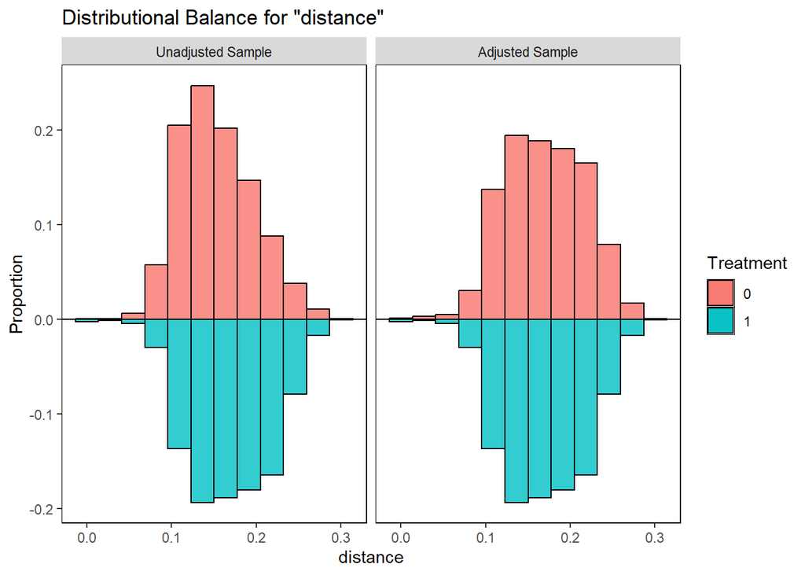

```r
# COMPROBAR EQUILIBRIO RESULTANTE
bal.plot(m.ps.train.1, var.name = "distance", type = "histogram", which = "both",
    mirror = TRUE)
```

Con este ‘balance plot’, se pretende representar la calidad del emparejamiento entre los grupos de tratados y no tratados. Más concretamente, se representa la comparación entre los individuos tratados y no tratados, antes y después del emparejamiento.